# BIS101 F2013 Lecture 6: Population Genetics

## Population genetics

#### What is a population?

a group of individuals of the same species, usually within some geographically delimited area, usually with the possibility of intermating

#### Evolution:

change in frequency of an allele over time (not the same as natural selection)

#### Frequency

| $A_1A_1$ | $A_1A_2$ | $A_2A_2$ |
| --- | --- | --- |
| 20 | 13 | 17 |

- what’s the *genotype frequency* of $A_1A_1$ **?** 40% (20/50)
- what is the allele frequency of $A_2$ **?** (p=47% or 0.47 because 34+13/100)
- what is the frequency of $A_1$ **?** (1-p)=0.53 b/c has to add to 1

I come back in 10 years, pop is now $A_1A_1$ 80 $A_1A_2$ 52 and $A_2A_2$ 68

Has evolution occurred **?** (not at this locus)

**Population genetics is the study of allele frequency change in populations**

Could argue it is synonymous with evolution

We also care about it because it has effect on phenotypes!

In talking quant gen, we showed phonos for a cross where at each het we have 1:2:1 segregation in F2, but in a population phenotype distribution determined by allele freqs.

So distribution would be freq. of genotype * value, e.g.

Using our model of two loci with each big letter adding 1 to phenotype, @ locus A $p_A=0.2$ and at locus B $p_B=0.3$

[figure not shown]

Now change allele frequencies to pA=0.5 and pB=0.9 and redraw. New mean phenotype = 2.8. So allele frequencies will affect mean phenotype in pop without changing any of the genetics!

## Hardy-Weinberg Equilibrium

- We talked about Mendel. HWE **NOT** 1:2:1
- Hardy & Weinberg 1908 (Hardy palyed crickey w/ Punnet)
- How to solve provlem of blending & loss of diversity
- Model (what’s a model **?** ) (what’s an equilibrium?)
  - model is a simplified description (mathematical) of a system
  - most of the time oversimplified – “all models are wrong, some models are useful”
  - focus on the important parts of a system (noise in biology)
  - allow predictions of expected outcome & comparison to real data
  - if obs. data do not fit model – biological interesting
  - assumptions wrong, try new model
  - what if data fit model? (my model is that aliens came down from outerspace and put chalk in the room)
  - data consistent w/ model doesn’t PROVE model (that’s how science works)

### HW Model (write on board assumptions)

Assumptions:

- autosomal (which is? )
- locus, 2 alleles, diploid
- mendelian segregation
- random mating
- no other evol. forces (which?)
- no selection
- no migration
- no mutation
- no drift (large. pop size -> inf.)
- equal freq. in both sexes (or all hermaphrodites)
- generations discrete and nonoverlapping (annual plant) (explain)

### Define variables (observed outcome of a system), parameters (things that define the model or system)

variables - X, Y, Z obs. freqs of 3 genotypes ($A_1A_1$, $A_1A_2$, $A_2A_2$) in our sample

parameter p = freq. $A_1$ allele, q=freq. $A_2$ allele = 1-p (why?)

if we have sample (not whole pop) of 18 $A_1A_1$ and 24 $A_1A_2$ and 8 $A_2A_2$

X=0.36, Y=0.48, Z=0.16

$p=X+\frac{Y}{2}=0.6$ (60 copies of A/100 total copies)

### Equations

In next generation:

| Gamete Table | prob. $A_1$ from parent1 | prob $A_2$ from parent1 |
| --- | --- | --- |
| prob $A_1$ from parent2 | $pp$ | $p(1-p)$ |
| prob $A_2$ from parent2 | $(1-p)p$ | $(1-p)(1-p)$ |

use prime to denote next generation

and $p'=X'+Y'/2$

and substituting: $p'=p^2+2p(1-p)/2 = p$ <- equilibrium

** In HWE, genetic composition (genotype and allele freqs) predictable w/ one parameter -> p **

Once in HWE, allele freqs. do not change (equilibrium) w/o disturbance

After a single generation of random mating -> HWE

- start with 0.2 $A_1A_1$ and 0.8 $A_2A_2$ -> figure out what’s p, and what’s p’ -> HWE after one generation

### Conclusions

Single generation of random mating will almost always -> HWE

Rare alleles more common in hets (p^2 < 2pq for whenever p < q)

[figure not shown]

Does dominance change HWE? - no because we haven’t said anything about phenotype – just genotype - so will recessive alleles go extinct **?**

Surprising # of loci in diff. organisms cannot reject HWE - does this mean no selection, drift, mutation **?** why not?

Informative: e.g. red hair. melanocortin 1 receptor MCR1. position 478 in the gene, if you are homozygous for the TT allele instead of the dominant C allele, you are a redhead with freckles.

In the US, the T alleles is at ~8% frequency. So redheads should be at what freq **?** = 0.64%. But between 2-6% of the population has red hair. What do conclude?

- assortative mating: maybe redheads mate with other redheads
- selection: maybe redheads are going to take over the world (unlikely)
- gene flow: immigration from countries with lots of redheads (irish, etc.?)
- multiple loci: maybe MCR1 is not only locus involved – in fact we know there are multiple mutations in MCR1 that can cause redhead, so a likely option.

Can use Chi-square to test if loci are in HWE!

- e.g.sample AA= 72 (68.1) Aa = 21 (28.9) aa = 7 (3.1) <- show this for yourself
  - X^2 >7.28 so not in HWE (tell them to show for selves)
- e.g. AA= 82 Aa = 38 aa = 5
  - is in nigh-perfect HWE (test it)

### Violate an assumption

Can show effects of violating an assumption (nonequal # of sexes etc.)

Some assumptions have sm. FX

- nonequal sexes, takes longer than 1 gen of random mating to reach HWE but still reach it
- drift or selection -> never reach
- nonrandom mating: include parameter F and can rewrite HWE with inbreeding coefficient

## DRIFT

in HWE with $N==\infty$ inf what happens to allele freqs over time (nothing)

in small pops, random chance is imp. (think about freq. heads depends on sample size)

Smaller N -> more drift; Bigger N -> less drift

Draw on board 6 individuals (1 AA 3 Aa 2 aa ) (can do X^2 and show sample does not reject HWE)

- If this is whole pop.: (calculate freqs.) use die roller app to pick mates for next gen.
- Recalculate freqs. (has evolution happened?)
- do a couple more (maybe until fixation?)

Other things associated with drift (define):

- bottleneck
- founder effect

Other deviations from HWE cause drift – separate sexes, etc, uneven offspring production. Humans have as much drift as a theoretical pop of size 10K in spite of being 7Billion of us!

Effective pop size: size of a theoretical population meeting all assumptions that has same allele freq. behavior as your pop.

- because most pops violate assumptions, Ne almost always << N
- Ne is what matters for drift.
  - Big census size w/ lots of size fluctuation similar drift to smaller pop w/ constant size
- e.g. Ne for Humans is 10K
- for dairy cows 100
- for drosophila 2M

Will skip the math, but:

Drift causes inbreeding: random mating in pop of sample 10, soon you’re mating w/ relatives by random!

Chance of fixation = frequency. So most new mutations (at freq. 1/2N) are lost by to drift!

Differences between species: 2N*mu mutations per gen. * 1/2N chance of fixing = mu differences between species per gen. (or between genes, i.e. Ks)

## Selection

Natural Selection not same as evolution

- change in frequency of a variant due to its effect on fitness
- multiple components to fitness: viability, mating success, fecundity
- Think in terms of relative fitness: some most fit genotype, and all other genotypes are competing with it
- variant that makes you compete better and make more copies of your genes -> natural selection will increase freq.

Fitness Table

relative fitness of $A_1A_1$ is $w_{11}$

- not faster than the bear, faster than the other guy

mean fitness of populatons is weighted avg.

{w} = $p^2w_{11}+2p(1-p)w_{12}+w_{22}(1-p)^2$

genotype freq. change depends on rel. fitness, so

- $X'=\frac{p^2w_{11}}{\bar{w}}$
- $Y'=\frac{2p(1-p)w_{12}}{\bar{w}}$
- $Z'=\frac{(1-p)^2w_{22}}{\bar{w}}$

can do some math and show allele freq:

- $p'= \frac{p(pw_{11}+(1-p)w_{12})}{\bar{w}}$

### results:

- change in allele freq. depends on difference in fitness b/t heterozygote and homozygote for the allele
- allele freq. (greater change with more middling allele freq)
- stronger s -> faster change in p,
- this general formula allows variation.
  - e.g. w11=1 w12=1-s w22=1-2s – when het is intermediate additive or incomplete dominance
  - w11=1 w12=1 w22=1-s (dominance of $A_1$)
  - w11=1 w12=1-s w22=1-s (recessive $A_1$)
- draw graph for recessive, dominant, codominant

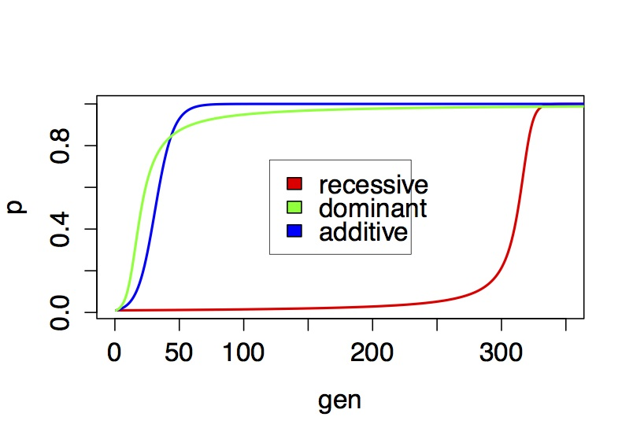

## Other forces

Gene flow: movement of genes from one population to another

- can impact allele frequencies and counteract selection and drift
- different pops should drift independently, but even one migrant/generation enough to prevent extensive divergence

Mutation

- fairly straightforward, increases freq of particular allele

## Combos

Mutation-selection balance:

- assuming selection against recessive: $p=\frac{\mu}{s^0.5}$
- for a completely recessive mutation, even under lethal selection (s=1) the freq. of A will be $\mu$